# IMDB Movie Database Analysis

Deepak Kumar

2017-07-19

# Loading required libraries

```r
setwd("C:/Users/Deepak kumar/Downloads")
library(ggplot2)
library(dplyr)
library(plotly)
library(formattable)
library(ggcorrplot)
```

# Loading the data,

```r
movie=read.csv("movie_metadata.csv",stringsAsFactors = FALSE,header=TRUE)
glimpse(movie)
```

```
## Observations: 5,043
## Variables: 28
## $ color                     <chr> "Color", "Color", "Color", "Color", ...
## $ director_name             <chr> "James Cameron", "Gore Verbinski", "...
## $ num_critic_for_reviews    <int> 723, 302, 602, 813, NA, 462, 392, 32...
## $ duration                  <int> 178, 169, 148, 164, NA, 132, 156, 10...
## $ director_facebook_likes   <int> 0, 563, 0, 22000, 131, 475, 0, 15, 0...
## $ actor_3_facebook_likes    <int> 855, 1000, 161, 23000, NA, 530, 4000...
## $ actor_2_name              <chr> "Joel David Moore", "Orlando Bloom",...
## $ actor_1_facebook_likes    <int> 1000, 40000, 11000, 27000, 131, 640,...
## $ gross                     <int> 760505847, 309404152, 200074175, 448...
## $ genres                    <chr> "Action|Adventure|Fantasy|Sci-Fi", "...
## $ actor_1_name              <chr> "CCH Pounder", "Johnny Depp", "Chris...
## $ movie_title               <chr> "AvatarÂ ", "Pirates of the Caribbea...
## $ num_voted_users           <int> 886204, 471220, 275868, 1144337, 8, ...
## $ cast_total_facebook_likes <int> 4834, 48350, 11700, 106759, 143, 187...
## $ actor_3_name              <chr> "Wes Studi", "Jack Davenport", "Step...
## $ facenumber_in_poster      <int> 0, 0, 1, 0, 0, 1, 0, 1, 4, 3, 0, 0, ...
## $ plot_keywords             <chr> "avatar|future|marine|native|paraple...
## $ movie_imdb_link           <chr> "http://www.imdb.com/title/tt0499549...
## $ num_user_for_reviews      <int> 3054, 1238, 994, 2701, NA, 738, 1902...
## $ language                  <chr> "English", "English", "English", "En...
## $ country                   <chr> "USA", "USA", "UK", "USA", "", "USA"...
## $ content_rating            <chr> "PG-13", "PG-13", "PG-13", "PG-13", ...
## $ budget                    <dbl> 237000000, 300000000, 245000000, 250...
## $ title_year                <int> 2009, 2007, 2015, 2012, NA, 2012, 20...
## $ actor_2_facebook_likes    <int> 936, 5000, 393, 23000, 12, 632, 1100...
## $ imdb_score                <dbl> 7.9, 7.1, 6.8, 8.5, 7.1, 6.6, 6.2, 7...
## $ aspect_ratio              <dbl> 1.78, 2.35, 2.35, 2.35, NA, 2.35, 2....
## $ movie_facebook_likes      <int> 33000, 0, 85000, 164000, 0, 24000, 0...
```

```r
summary(movie)
```

```
##     color           director_name      num_critic_for_reviews
##  Length:5043        Length:5043        Min.   :  1.0
##  Class :character   Class :character   1st Qu.: 50.0
##  Mode  :character   Mode  :character   Median :110.0
##                                        Mean   :140.2
##                                        3rd Qu.:195.0
##                                        Max.   :813.0
##                                        NA's   :50
##     duration     director_facebook_likes actor_3_facebook_likes
##  Min.   :  7.0   Min.   :    0.0         Min.   :    0.0
##  1st Qu.: 93.0   1st Qu.:    7.0         1st Qu.:  133.0
##  Median :103.0   Median :   49.0         Median :  371.5
##  Mean   :107.2   Mean   :  686.5         Mean   :  645.0
##  3rd Qu.:118.0   3rd Qu.:  194.5         3rd Qu.:  636.0
##  Max.   :511.0   Max.   :23000.0         Max.   :23000.0
##  NA's   :15      NA's   :104             NA's   :23
##  actor_2_name       actor_1_facebook_likes     gross
##  Length:5043        Min.   :     0         Min.   :      162
##  Class :character   1st Qu.:   614         1st Qu.:  5340988
##  Mode  :character   Median :   988         Median : 25517500
##                     Mean   :  6560         Mean   : 48468408
##                     3rd Qu.: 11000         3rd Qu.: 62309438
##                     Max.   :640000         Max.   :760505847
##                     NA's   :7              NA's   :884
##     genres          actor_1_name       movie_title
##  Length:5043        Length:5043        Length:5043
##  Class :character   Class :character   Class :character
##  Mode  :character   Mode  :character   Mode  :character
##
##
##
##
##  num_voted_users   cast_total_facebook_likes actor_3_name
##  Min.   :      5   Min.   :     0            Length:5043
##  1st Qu.:   8594   1st Qu.:  1411            Class :character
##  Median :  34359   Median :  3090            Mode  :character
##  Mean   :  83668   Mean   :  9699
##  3rd Qu.:  96309   3rd Qu.: 13756
##  Max.   :1689764   Max.   :656730
##
```

[output cut: 25 more lines]

```
##  Min.   :     0         Min.   :1.600   Min.   : 1.18
##  1st Qu.:   281         1st Qu.:5.800   1st Qu.: 1.85
##  Median :   595         Median :6.600   Median : 2.35
##  Mean   :  1652         Mean   :6.442   Mean   : 2.22
##  3rd Qu.:   918         3rd Qu.:7.200   3rd Qu.: 2.35
##  Max.   :137000         Max.   :9.500   Max.   :16.00
##  NA's   :13                             NA's   :329
##  movie_facebook_likes
##  Min.   :     0
##  1st Qu.:     0
##  Median :   166
##  Mean   :  7526
##  3rd Qu.:  3000
##  Max.   :349000
##
```

# Data Cleaning

## Remove unnecessary columns

I feel that color,plotkeywords,imdb link,facenumber in poster,aspect ratio to be unncessary for our visualisation analysis.They might be used for ML .But the kernel primary purpose is to analyse the data.

```r
movie$color=NULL
movie$facenumber_in_poster=NULL
movie$plot_keywords=NULL
movie$aspect_ratio=NULL
movie$movie_imdb_link=NULL
names(movie)
```

```
##  [1] "director_name"             "num_critic_for_reviews"
##  [3] "duration"                  "director_facebook_likes"
##  [5] "actor_3_facebook_likes"    "actor_2_name"
##  [7] "actor_1_facebook_likes"    "gross"
##  [9] "genres"                    "actor_1_name"
## [11] "movie_title"               "num_voted_users"
## [13] "cast_total_facebook_likes" "actor_3_name"
## [15] "num_user_for_reviews"      "language"
## [17] "country"                   "content_rating"
## [19] "budget"                    "title_year"
## [21] "actor_2_facebook_likes"    "imdb_score"
## [23] "movie_facebook_likes"
```

### Rename the column names

since the column names have _ in them let us rename them,

```r
name=c("dirname","noofcrit","duration","dirfblike","act3fblik","act2name","act1fblik","gross","genre","hero","title","voteuser","castvotefb","act3name","userrev","lang","country","contentrating","budget","titleyr","act2fblik","imdbscore","moviefblik")
colnames(movie)=name
names(movie)
```

```
##  [1] "dirname"       "noofcrit"      "duration"      "dirfblike"
##  [5] "act3fblik"     "act2name"      "act1fblik"     "gross"
##  [9] "genre"         "hero"          "title"         "voteuser"
## [13] "castvotefb"    "act3name"      "userrev"       "lang"
## [17] "country"       "contentrating" "budget"        "titleyr"
## [21] "act2fblik"     "imdbscore"     "moviefblik"
```

# Maximum movie made by director

```r
length(unique(movie$dirname))
```

```
## [1] 2399
```

```r
r=movie %>%filter(!(is.na(movie$dirname)| movie$dirname=="")) %>% group_by(dirname) %>% summarise(count=n()) %>% arrange(desc(count)) %>% top_n(20) %>% ggplot(aes(dirname,count,fill=dirname))+geom_bar(stat="identity")+theme(legend.position="None",axis.text.x = element_text(angle=90,vjust=0.3))+labs(x="DirName",y="Count")+ggtitle("Director With Maximum Titles")
ggplotly(r)
```

```
## We recommend that you use the dev version of ggplot2 with `ggplotly()`
## Install it with: `devtools::install_github('hadley/ggplot2')`
```

[interactive chart not shown]

# Which director has highest average gross ?

```r
temp=movie %>% select(dirname,gross)
temp=temp %>% group_by(dirname) %>% summarise(avg=mean(gross))
temp=temp %>% arrange(desc(avg))
temp=na.omit(temp)
temp=temp[1:20,]
temp %>% formattable(list(avg=color_bar("red"),align='1'))
```

| dirname | avg |
| --- | --- |
| Joss Whedon | 432721657 |
| Lee Unkrich | 414984497 |
| Chris Buck | 400736600 |
| Tim Miller | 363024263 |
| George Lucas | 348283696 |
| Kyle Balda | 336029560 |
| Colin Trevorrow | 328092532 |
| Yarrow Cheney | 323505540 |
| Pete Docter | 313113780 |
| Pierre Coffin | 309775640 |
| Richard Marquand | 309125409 |
| James Cameron | 278303701 |
| Francis Lawrence | 271700394 |
| Dan Scanlon | 268488329 |
| Roger Allers | 253543668 |
| Robert Stromberg | 241407328 |
| Mark Andrews | 237282182 |
| Chris Miller | 234970706 |
| Andrew Adamson | 229988557 |
| Christopher Nolan | 226653447 |

# Which is the movie with all time higest gross:

[figure not shown]

```r
temp=movie %>% select(title,gross)
temp=temp %>% arrange(desc(gross))
temp=na.omit(temp)
temp=temp[1:20,]
ggplot(temp,aes(title,gross,fill=title))+geom_bar(stat="identity")+theme(axis.text.x = element_text(angle=90,vjust = 0.5),legend.position="None")+labs(x="Title",y="Gross")+ggtitle("All time highest grossing movie")
```

# Which year had maximum releases ?

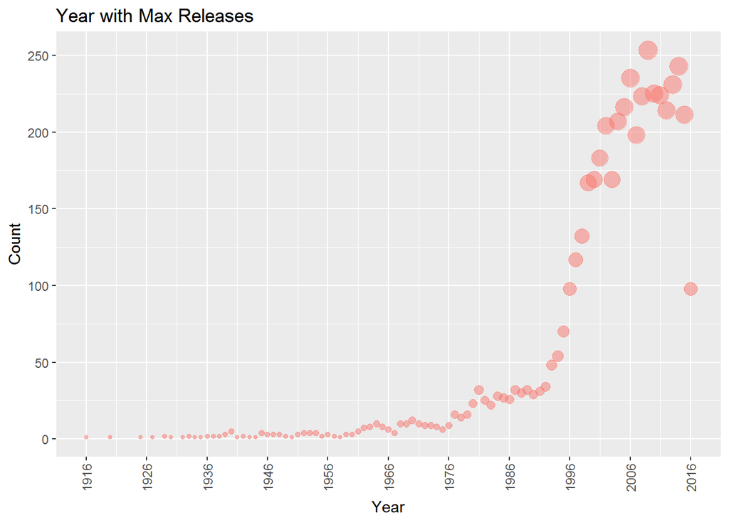

```r
temp=movie %>% select(titleyr,title)
temp =temp %>% group_by(titleyr) %>% summarise(count=n_distinct(title))
temp=na.omit(temp)
temp %>% ggplot(aes(titleyr,count,size=count))+geom_point(alpha=0.5,aes(color="red"))+theme(axis.text.x = element_text(angle=90,vjust=0.5),legend.position="None")+labs(x="Year",y="Count")+ggtitle("Year with Max Releases")+scale_x_continuous(breaks=seq(1916,2017,10))
```

# Which movie hax max voters and max critical reviews ?

```r
length(unique(movie$title))
```

```
## [1] 4917
```

```r
temp=movie %>% select(title,noofcrit,voteuser)
temp = temp %>% arrange(desc(temp$voteuser))
temp=temp[1:20,]
temp=na.omit(temp)
p=ggplot(temp,aes(voteuser,noofcrit))+geom_point(aes(color=title))+theme(axis.text.x = element_text(angle=90),legend.position="none")+labs(x="UserVote",y="NoofCriticsReview")+ggtitle("No of  User Vote Vs Critics Review")
ggplotly(p)
```

```
## We recommend that you use the dev version of ggplot2 with `ggplotly()`
## Install it with: `devtools::install_github('hadley/ggplot2')`
```

[interactive chart not shown]

As evident,Django Unchained has got maximum critics review where as user vote is in the minimum side.Shawshank Redemption has got maximum user reviews whereas critics review has been less.

# What is the content has got maximum user reviews over the year?

```r
temp=movie %>% select(userrev,contentrating,titleyr)
temp=temp %>% group_by(titleyr,contentrating) %>% summarise(avgrev=mean(userrev))
temp=temp %>% arrange(desc(titleyr))
temp=na.omit(temp)
q=ggplot(temp,aes(titleyr,avgrev,fill=contentrating))+geom_bar(stat="identity")+theme(axis.text.x = element_text(angle=90),legend.position="bottom")+labs(x="Year",y="Content Review")+ggtitle("Content rating each year")+scale_x_continuous(breaks =seq(1916,2017,2))
ggplotly(q)
```

```
## We recommend that you use the dev version of ggplot2 with `ggplotly()`
## Install it with: `devtools::install_github('hadley/ggplot2')`
```

[interactive chart not shown]

PG has been the top contender year on year generating maximum user reviews most of the time.

# Correlation of IMDB Score Vs User review,FB Likes,Critics review,User Vote,Cast vote in FB,budget,gross,FB Likes of a movie

Let us understand the correlation of the following factors with help of ggcorrplot.

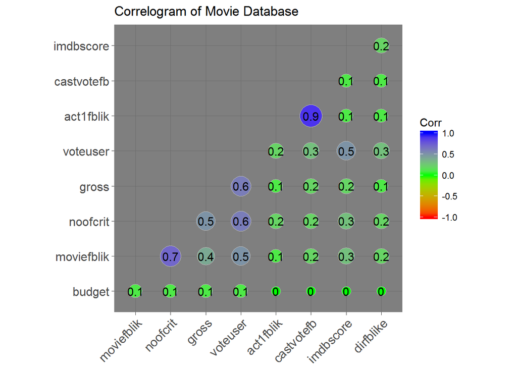

```r
temp = movie %>% select(imdbscore,dirfblike,act1fblik,gross,voteuser,castvotefb,budget,moviefblik,noofcrit)
temp=na.omit(temp)
corr=round(cor(temp),1)
ggcorrplot(corr,hc.order=TRUE,type="lower",lab=TRUE,lab_size=4,method="circle",colors=c("red","green","blue","pink","white"),title="Correlogram of Movie Database",ggtheme=theme_dark)
```

# How do the IMDB Scores vary by category??

```r
temp=movie %>% select(contentrating,imdbscore)
temp=na.omit(temp)
plot_ly(temp,x= ~temp$imdbscore,y=~temp$contentrating,type="box",color=temp$contentrating)
```

[interactive chart not shown]

We see that R has maximum outliers.The data seems to be skewed towards left.PG13 has also got similar skewness.